# Démonstrateur ASPE : construction des relations taille - poids

Pascal Irz

Le 17 mai 2021

# Objectif

Pour calculer des densités de biomasse piscicoles en $g$ (de poisson capturé) par $m^2$ prospecté, il faut disposer des … poids. Or les captures ne sont pas toujours pesées sur le terrain. Dans certains cas, seule la longueur est mesurée. Heureusement, da,s la grande majorité des cas, il existe une relation forte entre la taille d’un individu et son poids. En d’autres termes, il est possible d’estimer le poids du poisson à partir de sa taille.

Ces relations taille-poids se veulent aussi générales que possible, donc on veillera à ce que des observations atypiques, voire des erreurs dans la base de données, ne viennent pas les influencer exagérément. La dernière partie montre comment confronter les résultats issus de Aspe à ceux publiés dans la littérature.

Les fonctions du package `aspe` dédiées à ces traitements sont identifiées par le préfixe `qtp_`.

# Grandes lignes de l’analyse

## Principe

Le point de départ est l’hypothèse classique selon laquelle l’équation qui permet de relier la longueur d’un poisson à son poids est de la forme :

$Poids=a\cdot Longueur^b$

Les valeurs des coefficients $a$ et $b$ dépendent des unités qui sont, dans Aspe, les grammes et les millimètres.

Pour déterminer les valeurs des coefficients sur un jeu de données, les deux termes de l’égalité sont log-transformés pour prendre la forme :

$\log(Poids)=\log(a)+b\cdot log(Longueur)$

Il suffit d’effectuer la régression linéaire de $\log(Poids)$ en fonction de $log(Longueur)$, de récupérer les coefficients $\alpha=\log(a)$ et $\beta=b$, puis de calculer $a=e^{\alpha}$.

## Contraintes sur le jeu de données

L’analyse reposant sur la régression entre deux grandeurs, il est nécessaires que ces deux grandeurs :

- Soient mesurées avec une précision suffisante.
- Présentent une certaine variabilité.
- Soient mesurées sur un nombre suffisant d’individus.

Il faut aussi que les distributions des deux variables soient “raisonnablement” proches d’une gaussienne une fois log-transformées pour éviter que de potentiels *outliers* ne perturbent la relation générale.

## Chargement packages et données

```r
library(aspe)
library(tidyverse)

load(file = "raw_data/toutes_tables_aspe_sauf_mei.RData")
load(file = "raw_data/mei.RData")
```

# Gammes de taille et de poids

La première étape, pour éviter que des *outliers* ne perturbent les analyses, est de définir pour chaque jeu de données sur une espèce des gammes de longueurs et de poids “plausibles” en dehors desquelles les observations seront excles pour effectuer la régression. Dans la base, les poids (masses) sont en grammes et les longueurs en millimètres.

## Le jeu de données

Dans cet exemple, toutes les mesures individuelles de la base sont prises en compte.

> NB : Pour produire des relations taille - poids spécifiques à une région, en théorie il suffit de procéder de même après avoir filtré la table `mesure_individuelle`. En pratique, certaines espèces rares (peu d’individus) ou de très petite taille (erreurs relatives importantes de mesure du poids) peuvent bloquer la procédure.

Pour constituer le jeu de données, les étapes sont :

- La table `mesure_individuelle` est filtrée pour supprimer les observations avec taille ou poids manquant ou nul et ne conserver que les mesures réellement effectuées.
- Jointure sur la table `lot_poissons` pour obtenir l’identifiant Aspe de l’espèce.
- Jointure sur la table `ref_espece` pour obtenir le code à trois lettres de l’espèce.

Les jointures sont effectuées sur une sélection des colonnes des tables (fonction `select()`) afin d’éviter de surcharger le tableau de données avec des colonnes inutiles.

Il est possible de sélectionner uniquement les mesures de longueur à la fourche (`filter(mei_tlo_id == 1)`) ou bien les longueurs totales (`filter(mei_tlo_id == 2)`). Dans cet exemple toutes les mesures sont conservées.

```r
tp_data <- mesure_individuelle %>%
  filter(mei_taille > 0 & mei_poids > 0 & # tailles et poids positifs
         mei_mesure_reelle == "t") %>%
  left_join(y = lot_poissons %>% # jointure pour ajouter "lot_poissons"
              select(mei_lop_id = lop_id, esp_id = lop_esp_id, lop_tyl_id)) %>%
  filter(lop_tyl_id == 4) %>% # Type de lot correspondant aux mesures individuelles
  left_join(y = ref_espece %>%
              select(esp_id, esp_code_alternatif)) %>%
  select(-mei_sex_id, -(mei_poids_estime:mei_age), -lop_tyl_id, -esp_id, -mei_mesure_reelle)
```

Nombre de couples de mesures par espèce, en distinguant les longueurs à la fourche (`mei_tlo_id = 1`) et totales (`mei_tlo_id = 2`).

```r
obs_par_esp <- tp_data %>%
  group_by(esp_code_alternatif, mei_tlo_id) %>%
    tally() %>%
  ungroup() %>%
  pivot_wider(names_from = mei_tlo_id, values_from = n) %>%
  select(-"NA") %>%
  purrr::set_names(c("Espèce", "L. fourche", "L. totale")) %>%
  arrange(-`L. totale`)

obs_par_esp %>%
  DT::datatable(rownames = FALSE, width = 400) %>%
  DT::formatCurrency(c("L. fourche", "L. totale"), currency = "", interval = 3, mark = " ", digits = 0)
```

| Espèce | L. fourche | L. totale |
| --- | --- | --- |
| TRF | 47454 | 462599 |
| CHE | 10904 | 181024 |
| ANG | 1 | 123984 |
| GAR | 9193 | 96878 |
| GOU | 5187 | 58174 |
| BAF | 2209 | 56286 |
| CHA | 10 | 36777 |
| PER | 3517 | 32384 |
| VAN | 3694 | 25260 |
| BLN | 804 | 24793 |

[output cut: 94 more lines]

## Calcul des relations taille-poids

Il s’agit ici d’enchaîner “automatiquement” les étapes détaillées dans le [tuto dédié](https://rpubs.com/kamoke/729779) au moyen de la fonction `qtp_calcul()`.

Seules les espèces pour lesquelles une régression taille-poids a du sens doivent être conservées, faute de quoi il y a des risques d’erreurs.

Conversion des longueurs en *cm* et séparation du jeu de données entre longueur totale et longueur fourche.

```r
tp_data <- tp_data %>%
  mutate(mei_taille = mei_taille / 10)

tp_data_lt <- tp_data %>%
  filter(mei_tlo_id == 2)

tp_data_lf <- tp_data %>%
  filter(mei_tlo_id == 1)
```

### Pour les longueurs totales

```r
resume <- qtp_resume_donnees(df = tp_data_lt,
                             seuil_poids_absolu = 5)
```

```r
resume %>%
  mutate_if(is.numeric, round, 1) %>%
  DT::datatable()
```

|  | esp_code_alternatif | taille_mini | taille_maxi | poids_moyen | n_sup_seuil |
| --- | --- | --- | --- | --- | --- |
| 1 | ATH | 4 | 8.6 | 1.8 | 0 |
| 2 | BLX | 3.9 | 3.9 | 1 | 0 |
| 3 | LOB | 5.1 | 8 | 1.9 | 0 |
| 4 | PHX | 2.9 | 7.2 | 1.8 | 0 |
| 5 | PIM | 4.7 | 5.4 | 1 | 0 |
| 6 | BBP | 11.7 | 11.7 | 28 | 1 |
| 7 | GDL | 4.6 | 8.3 | 1.9 | 1 |
| 8 | GFL | 9.6 | 9.6 | 10 | 1 |
| 9 | MUD | 4.8 | 11.1 | 6 | 1 |
| 10 | CAK | 11.5 | 41 | 726.5 | 2 |

[output cut: 94 more lines]

Les espèces pour lesquelles seuls quelques individus passent le seuil du poids minimum ne peuvent faire l’objet d’une analyse fiable. Sélectionnons par exemple les espèces avec au minimum 20 individus dépassant le seuil.

```r
mes_especes <- resume %>%
  filter(n_sup_seuil > 19) %>%
  pull(esp_code_alternatif) %>%
  as.character()

mes_especes
```

```
##  [1] "ASP" "HYC" "LPR" "ALA" "CAR" "CAX" "GOL" "GKS" "PLI" "EPI" "CCU" "LOU"
## [13] "OBL" "TRM" "APR" "BAX" "MUC" "LOR" "LPX" "MGL" "TRL" "BOU" "CDR" "LPM"
## [25] "IDE" "CAD" "GTN" "PAP" "FLE" "SDF" "PSR" "VAR" "BBG" "CMI" "BLE" "CAG"
## [37] "MUP" "LOE" "SAN" "PCC" "LOT" "CAS" "VAI" "GRE" "TAC" "LPP" "CCO" "OBR"
## [49] "SAT" "APP" "OCL" "SPI" "PCH" "ROT" "SIL" "PFL" "TAN" "BRB" "BRE" "TOX"
## [61] "LOF" "ABL" "BRO" "PES" "BAM" "HOT" "CHA" "BLN" "VAN" "PER" "GOU" "BAF"
## [73] "GAR" "ANG" "CHE" "TRF"
```

Au total, 76 espèces comptent suffisamment d’individus.

Application de la fonction `qtp_calcul()` aux espèces sélectionnées.

```r
tp <- qtp_calcul(df = tp_data_lt,
                 especes = mes_especes) %>%
  mutate_at(vars(-esp_code_alternatif), as.numeric) %>%
  arrange(-n_ind)
```

```r
tp %>%
  DT::datatable(rownames = FALSE,
                options = list(columnDefs = list(list(className = 'dt-center',
                                                      targets = 0:3)))) %>%
  DT::formatRound(columns = c('a', 'b'), digits = 4) %>%
  DT::formatRound(columns = c('r2_ajuste'), digits = 2) %>%
  DT::formatRound(columns = c('taille_mini', 'taille_maxi', 'poids_mini'), digits = 1) %>%
  DT::formatCurrency(columns = c('n_ind', 'poids_maxi'), currency = "",
                     interval = 3, mark = " ", digits = 0)
```

| esp_code_alternatif | a | b | r2_ajuste | n_ind | taille_mini | taille_maxi | poids_mini | poids_maxi |
| --- | --- | --- | --- | --- | --- | --- | --- | --- |
| TRF | 0.011165042906082 | 2.98461320885157 | 0.984039607327813 | 407380 | 1 | 53 | 1 | 1100 |
| CHE | 0.00860892896282654 | 3.06886316146249 | 0.987206610464533 | 160288 | 0 | 58 | 1 | 1633 |
| ANG | 0.00109469323255009 | 3.12512665657048 | 0.977464127090243 | 114800 | 2 | 102 | 1 | 147747 |
| GAR | 0.0073098040104155 | 3.16105602549829 | 0.972134048038624 | 82330 | 1 | 38 | 1 | 539 |
| BAF | 0.0121661447643773 | 2.90769527021218 | 0.988613494484041 | 48240 | 1 | 74 | 1 | 2207 |
| GOU | 0.013862698871886 | 2.89037709509078 | 0.886261304357347 | 42167 | 1 | 20 | 1 | 68 |
| PER | 0.0104781543017559 | 3.06734558009324 | 0.972755687177899 | 27599 | 1 | 46 | 1 | 611 |
| VAN | 0.00883030448468262 | 3.04845498749186 | 0.973688398759616 | 20920 | 1 | 47 | 1 | 669 |
| BLN | 0.0144515042422935 | 2.8688042566855 | 0.92083792117015 | 20614 | 1 | 25 | 1 | 121 |
| CHA | 0.0457668932226008 | 2.47600040556008 | 0.823778810785504 | 19956 | 0 | 16 | 1 | 51 |

[output cut: 66 more lines]

Certaine des $r^2$ ajustés ne font pas rêver. On va considérer que s’il est inférieur à 0.8, la relation n’est pas utilisable.

```r
tp_lt <- tp %>%
  filter(r2_ajuste > 0.8) %>%
  mutate(tlo_id = 2)
```

### Pour les longueurs fourche

```r
resume <- qtp_resume_donnees(df = tp_data_lf,
                             seuil_poids_absolu = 5)
```

```r
resume %>%
  mutate_if(is.numeric, round, 1) %>%
  DT::datatable()
```

|  | esp_code_alternatif | taille_mini | taille_maxi | poids_moyen | n_sup_seuil |
| --- | --- | --- | --- | --- | --- |
| 1 | ATH | 3 | 3 | 2 | 0 |
| 2 | CYP | 1 | 5.6 | 1.3 | 0 |
| 3 | EPI | 4 | 4 | 1 | 0 |
| 4 | ANG | 20 | 20 | 10 | 1 |
| 5 | CAR | 7.5 | 7.5 | 10 | 1 |
| 6 | CCU | 4.5 | 70 | 2500.7 | 1 |
| 7 | LPP | 17 | 17 | 8 | 1 |
| 8 | PCH | 23.4 | 23.4 | 166 | 1 |
| 9 | APP | 3.5 | 10.5 | 17.6 | 2 |
| 10 | ASP | 12.8 | 28.5 | 157.5 | 2 |

[output cut: 48 more lines]

Les espèces pour lesquelles seuls quelques individus passent le seuil du poids minimum ne peuvent faire l’objet d’une analyse fiable. Sélectionons par exemple les espèces avec au minimum 20 individus dépassant le seuil.

```r
mes_especes <- resume %>%
  filter(n_sup_seuil > 19) %>%
  pull(esp_code_alternatif) %>%
  as.character()

mes_especes
```

```
##  [1] "BOU" "CAD" "CAG" "LOU" "CMI" "PSR" "BBG" "SDF" "SPI" "SAN" "VAI" "VAR"
## [13] "TAC" "TOX" "TRM" "MUP" "CAS" "ROT" "BRB" "CCO" "TAN" "GRE" "BAM" "BRE"
## [25] "ABL" "HOT" "BLN" "PES" "BRO" "OBR" "BAF" "PER" "VAN" "GOU" "SAT" "GAR"
## [37] "CHE" "TRF"
```

Au total, 38 espèces comptent suffisamment d’individus.

Application de la fonction `qtp_calcul()` aux espèces sélectionnées.

```r
tp <- qtp_calcul(df = tp_data_lf,
                 especes = mes_especes) %>%
  mutate_at(vars(-esp_code_alternatif), as.numeric) %>%
  arrange(-n_ind)
```

Résultat avec un peu de mise en forme :

```r
tp %>%
  DT::datatable(rownames = FALSE,
                options = list(columnDefs = list(list(className = 'dt-center',
                                                      targets = 0:3)))) %>%
  DT::formatRound(columns = c('a', 'b'), digits = 4) %>%
  DT::formatRound(columns = c('r2_ajuste'), digits = 2) %>%
  DT::formatRound(columns = c('taille_mini', 'taille_maxi', 'poids_mini'), digits = 1) %>%
  DT::formatCurrency(columns = c('n_ind', 'poids_maxi'), currency = "",
                     interval = 3, mark = " ", digits = 0)
```

| esp_code_alternatif | a | b | r2_ajuste | n_ind | taille_mini | taille_maxi | poids_mini | poids_maxi |
| --- | --- | --- | --- | --- | --- | --- | --- | --- |
| TRF | 0.0132499975095524 | 2.95029226955293 | 0.985295091598441 | 42653 | 2 | 57 | 1 | 810 |
| CHE | 0.00940404829989562 | 3.0648009209989 | 0.98162901173285 | 9532 | 1 | 59 | 1 | 2106 |
| GAR | 0.00894278803009254 | 3.15424568230003 | 0.946971378398781 | 7843 | 0 | 36 | 1 | 583 |
| SAT | 0.0098893927880457 | 3.0780353398858 | 0.968677419176812 | 4195 | 3 | 91 | 1 | 4997 |
| GOU | 0.0148360551674997 | 2.90550388468857 | 0.862836877366294 | 3978 | 2 | 24 | 1 | 114 |
| VAN | 0.00669520163385269 | 3.20661878631192 | 0.974078430417395 | 3100 | 1 | 36 | 1 | 457 |
| PER | 0.0120923120403372 | 3.02788238372873 | 0.958947851689715 | 2977 | 1 | 42 | 1 | 582 |
| BAF | 0.0115099200914235 | 2.93833247681328 | 0.986731776107114 | 1850 | 1 | 64 | 1 | 9883 |
| OBR | 0.00858947997203493 | 3.04741566442716 | 0.986201774191351 | 965 | 5 | 46 | 1 | 864 |
| BRO | 0.00672815081538774 | 3.00766429975904 | 0.985708369172201 | 833 | 5 | 108 | 1 | 7605 |

[output cut: 28 more lines]

Suppression des $r^2$ ajustés inférieurs à 0.5.

```r
tp_lf <- tp %>%
  filter(r2_ajuste > 0.5) %>%
  mutate(tlo_id = 1)
```

### Assemblage des deux tables

```r
tp_aspe <- rbind(tp_lf, tp_lt)
rownames(tp) <- NULL
```

### Exportation / sauvegarde

Pour une exploitation avec R :

```r
save(tp_aspe, file = "processed_data/tp_aspe.RData")
```

Pour une exploitation avec un tableur :

```r
write.csv2(tp_aspe, file = "processed_data/tp_aspe.csv", row.names = FALSE)
```

# Complément par Fishbase

[figure not shown]

Le package {rfishbase} ([Boettiger, Lang & Wainwright 2012](https://fishlab.ucdavis.edu/wp-content/uploads/sites/397/2011/01/BoettigerFishbase2012.pdf)) est une interface pour utiliser avec R les données compilées dans Fishbase sur plusieurs milliers d’espèces.

Il a été et a largement enrichi depuis 2012 pour suivre les évolutions de Fishbase et est accompagné d’un [tutoriel](https://docs.ropensci.org/rfishbase).

On peut donc comparer nos résultats avec des données de Fishbase.

## Sur une espèce

### Téléchargement des données Fishbase

Il faut d’abord charger le package {rfishbase} puis utiliser sa fonction `length_weight()`.

Installation du package {rfishbase}.

```r
install.packages("rfishbase")
```

Chargement des données.

Exemple avec la tanche, *Tinca tinca* (la fonction permettrait de charger les relations pour plusieurs espèces à la fois).

```r
nom_latin <- "Tinca tinca" # choix de l'espèce

fb_data <- rfishbase::length_weight(nom_latin) %>%
  filter(is.na(EsQ)) %>% # suppression données taguées douteuses
  select(a, b, r2_ajuste = CoeffDetermination, n_ind = Number, taille_mini = LengthMin,
         taille_maxi = LengthMax, lieu = Locality)
```

Création d’un objet `lieu` pour localiser notre étude.

```r
lieu <- data.frame(lieu = "France - ASPE")
```

Assemblage des tableaux. Il s’agit d’empiler nos résultats pour une espèce avec ceux de Fishbase. La présente étude figure sur la première ligne.

```r
synthese <- tp %>%
  filter(esp_code_alternatif == "TAN") %>% # seulement la tanche
  cbind(lieu) %>% # ajout du lieu comme une colonne
  select(names(fb_data)) %>% # agencement des colonnes dans le même ordre que celles de fb_data
  rbind(fb_data) # empilement
```

Comme les intitulés des lieux d’étude sont assez moches (parfois les années, les coordonnées etc.) on peut les nettoyer un peu en utilisant les fonctions de traitement des chaînes de caractères du package `stringr` qui a fait partie de `tidyverse` (donc qui est déjà activé).

```r
synthese <- synthese %>%
  qtp_nettoyer_fb_lieu()
```

Tableau mise en forme :

```r
synthese %>%
    DT::datatable(rownames = FALSE) %>%
    DT::formatRound(columns = c('a', 'b'), digits = 5) %>%
    DT::formatRound(columns = c('r2_ajuste'), digits = 2) %>%
    DT::formatRound(columns = c('taille_mini', 'taille_maxi'), digits = 1) %>%
    DT::formatCurrency(columns = c('n_ind'), currency = "",
                       interval = 3, mark = " ", digits = 0)
```

| a | b | r2_ajuste | n_ind | taille_mini | taille_maxi | lieu |
| --- | --- | --- | --- | --- | --- | --- |
| 0.0147618948340863 | 3.04234497520775 | 0.989833183437729 | 429 | 2 | 52 | France ASPE |
| 0.0116 | 3 |  |  |  |  |  |
| 0.0305 | 2.964 | 0.98943 |  | 20 | 41 | Volga river |
| 0.013 | 3.026 | 0.996 | 52 | 7.5 | 43.5 | La Nava Reservoir, Navarra |
| 0.0071 | 3.25 | 0.983 | 68 | 13.1 | 35 | Lake Sapanca, Marmara, Jan. May |
| 0.0372 | 2.74 | 0.999 | 6 | 17 | 25.6 | Terkos Dam, Marmara |
| 0.009 | 3.319 | 0.99 | 47 | 4.3 | 25.3 | Ergis River |
| 0.0027 | 2.78 | 0.97 | 223 | 11 | 26.5 | Seyhan Dam |
| 0.0105 | 3.118 | 0.99 | 2244 | 2 | 55.8 | Flanders |

### Mise en perspective graphique

On peut reproduire le type de graphique que propose Fishbase pour situer les relations taille - poids les unes par rapport aux autres.

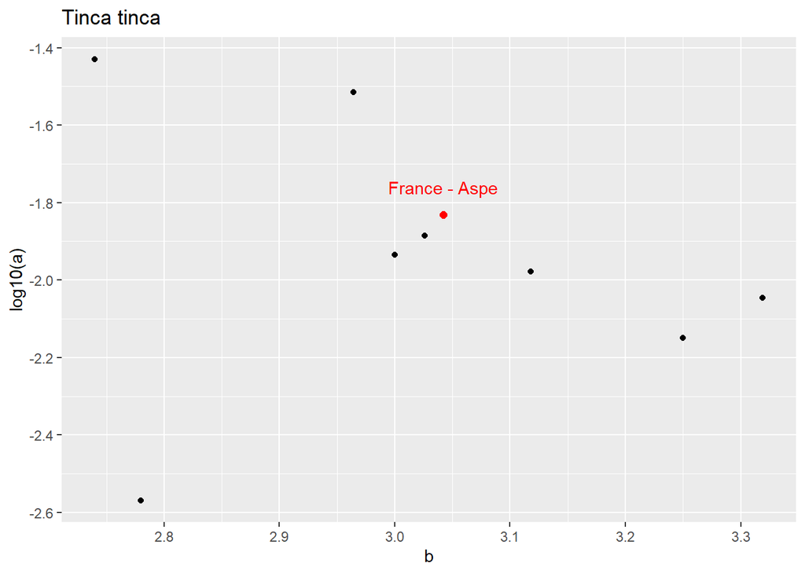

```r
g <- ggplot(data = synthese, aes(x = b, y = log(a, base = 10), text = lieu)) +
  geom_point() +
  geom_point(data = synthese[1,], color = "red", size = 2) +
  geom_text(data = synthese[1,], color = "red", label = "France - Aspe", nudge_y = 0.07) +
  labs(y = "log10(a)", title = nom_latin)
g
```

```r
# plotly::ggplotly(g, tooltip = "text")
```

Il est rassurant que notre point ne tombe pas totalement en dehors du nuage de points. Le point en bas à gauche est pour le moins douteux.

# Taille-poids sur l’ensemble des espèces

Il s’agit ici de compléter les relations obtenues à partir de Aspe par celles de Fishbase pour obtenir les équations de conversions pour **toutes** les espèces de poissons de la base Aspe. Le tableau ainsi obtenu permettra donc d’évaluer les poids de tous les individus ou lots qui n’ont pas été pesés.

Comme la requête depuis Fishbase requiert les noms scientifiques des espèces au format *genre espèce* en deux mots, on prépare la liste des noms à partir du *dataframe* `resume` en supprimant ce qui est entre parenthèses et au-delà du deuxième mot. Par exemple *Salmo trutta fario* devient *Salmo trutta*.

Quand la détermination a été approximée au genre, c’est qu’il y a hésitation entre plusieurs espèces morphologiquement très proches, donc il n’est pas génant de prendre la relation taille - poids d’une des espèces possible. Ainsi, on recode les *Carassius* déterminés seulement au genre en *Carassius carassius*. On procède de même pour les (rares) taxons pour lesquels aucune donnée taille-poids n’est publiée sur Fishbase (ex : *Gobio occitaniae*, *Pungitius pungitius*) en longueur fourche ou totale.

On corrige aussi une erreur de frappe sur *Micropterus dolomieu* qui est orthographié *Micropterus dolomieui* dans la table `ref_espece`.

```r
especes <- tp_data %>%
  select(esp_code_alternatif) %>%
  left_join(y = ref_espece %>%
     select(esp_code_alternatif, esp_nom_latin)) %>%
  distinct() %>%
  mutate(esp_nom_latin = str_replace(esp_nom_latin, # suppression du contenu entre parenthèses
                                     pattern = " \\s*\\([^\\)]+\\)",
                                     replacement = ""),
         esp_nom_latin_n_mots = str_count(esp_nom_latin, "\\S+"), # calcul du nb de mots
         esp_nom_latin = ifelse(esp_nom_latin_n_mots == 1, # suppression des mots au-delà du 2e
                                yes = word(esp_nom_latin, 1, 1, sep = " "),
                                no =  word(esp_nom_latin, 1, 2, sep = " ")),
         esp_nom_latin = case_when(
           esp_nom_latin == "Blicca" ~ "Blicca bjoerkna", # détermination au genre
           esp_nom_latin == "Abramis" ~ "Abramis brama",
           esp_nom_latin == "Barbus" ~ "Barbus barbus",
           esp_nom_latin == "Carassius" ~ "Carassius carassius",
           esp_nom_latin == "Coregonus" ~ "Coregonus lavaretus",
           esp_nom_latin == "Cyprinidae" ~ "Rutilus rutilus",
           esp_nom_latin == "Gobio" ~ "Gobio gobio",
           esp_nom_latin == "Lampetra" ~ "Lampetra fluviatilis",
           esp_nom_latin == "Micropterus" ~ "Micropterus salmoides",
           esp_nom_latin == "Phoxinus" ~ "Phoxinus phoxinus",
           esp_nom_latin == "Liza aurata" ~ "Chelon auratus", # espèce renommée
           esp_nom_latin == "Gobio occitaniae" ~ "Gobio gobio", # recodage par espèce proche
           esp_nom_latin == "Cobitis bilineata" ~ "Cobitis taenia", # idem
           esp_nom_latin == "Proterorhinus semilunaris" ~ "Proterorhinus marmoratus", # idem
           esp_nom_latin == "Pungitius pungitius" ~ "Gasterosteus aculeatus", # idem
           esp_nom_latin == "Micropterus dolomieui" ~ "Micropterus dolomieu", # faute de frappe sur le nom
           TRUE ~ esp_nom_latin),
         esp_nom_latin = str_squish(esp_nom_latin)) %>% # suppression des espaces qui trainent
  select(-esp_nom_latin_n_mots)
```

Ensuite on collecte les paramètres depuis Fishbase. Les données taguées douteuses sont supprimées, sauf pour *Telestes souffia* car il n’y a qu’une donnée sur Fishbase. Faute de mieux on la conserve.

```r
tp_fb <- especes %>%
  pull(esp_nom_latin) %>%
  unique() %>%
  rfishbase::length_weight() %>%
  filter(is.na(EsQ) | Species == "Telestes souffia") %>% # suppression données taguées douteuses
  select(esp_nom_latin = Species,
         tlo_id = Type,
         a, b,
         r2_ajuste = CoeffDetermination,
         n_ind = Number,
         taille_mini = LengthMin,
         taille_maxi = LengthMax,
         lieu = Locality) %>%
  mutate(tlo_id = ifelse(is.na(tlo_id), "TL", tlo_id)) %>%
  filter(tlo_id %in% c("TL", "FL")) %>% # on ne garde que les longueurs fourche ou totale
  qtp_nettoyer_fb_lieu() # nettoyage du champ "lieu"
```

A partir de ce tableau, on agrège par espèce et type de longueur.

> NB La relation taille - poids étant de type puissance, on retient pour les paramètres $a$ et $b$ “moyens” respectivement les moyennes géométrique et arithmétique (méthode retenue par Fishbase).

```r
tp_fb <- tp_fb %>%
  mutate(tlo_id = ifelse(tlo_id == "TL", 2, 1)) %>%
  group_by(esp_nom_latin, tlo_id) %>%
    summarise(a = exp(mean(log(a))), # moyenne géométrique
              b = mean(b), # moyenne arithmétique
              n_etudes = n(),
              source = "Fishbase") %>% # nb d'études
  left_join(y = especes) %>%
  select(esp_code_alternatif, esp_nom_latin, tlo_id, a, b, source) %>%
  filter(!is.na(a))
```

Mise en forme du tableau `tp_aspe` pour qu’il puisse être superposé avec `tp_fb` (colonnes dans le même ordre).

```r
tp_aspe <- tp_aspe %>%
  mutate(source = "ASPE") %>%
  left_join(y = ref_espece %>%
              select(esp_code_alternatif, esp_nom_latin)) %>%
  select(names(tp_fb))
```

Les deux tableaux sont superposés.

```r
tp <- rbind(tp_fb, tp_aspe) %>%
  arrange(esp_code_alternatif, tlo_id)
```

| esp_code_alternatif | esp_nom_latin | tlo_id | a | b | source |
| --- | --- | --- | --- | --- | --- |
| ABH | Leucaspius delineatus | 2 | 0.0069 | 3.103 | Fishbase |
| ABL | Alburnus alburnus | 1 | 0.0184521130293779 | 2.68073930528863 | ASPE |
| ABL | Alburnus alburnus | 2 | 0.00738380353895199 | 3.01 | Fishbase |
| ABL | Alburnus alburnus | 2 | 0.0291635138018599 | 2.46161449246738 | ASPE |
| ALA | Alosa alosa | 2 | 0.00764444712753301 | 3.057625 | Fishbase |
| ALF | Alosa fallax | 2 | 0.00514326203106859 | 3.0866 | Fishbase |
| ANG | Anguilla anguilla | 2 | 0.00108629108112518 | 3.13271632653061 | Fishbase |
| ANG | Anguilla anguilla | 2 | 0.00109469323255009 | 3.12512665657048 | ASPE |
| APP | Austropotamobius pallipes | 2 | 0.0373194931066144 | 2.96263163097818 | ASPE |
| APR | Zingel asper | 2 | 0.0196357062135393 | 2.69345945727977 | ASPE |

[output cut: 211 more lines]

Pour contrôler si le tableau `tp` contient au moins une relation taille-poids pour chacune des espèces de poisson de la base Aspe, on peut chercher les `esp_code_alternatif` présents dans `tp_data` mais qui seraient absents de `tp`.

| esp_code_alternatif | esp_nom_commun | esp_nom_latin |
| --- | --- | --- |
| ASA | Ecrevisse à pieds rouges | Astacus astacus |
| ASL | Ecrevisse à pieds grêles | Astacus leptodactylus |
| CRC | Crabe chinois | Eriocheir sinensis |
| OCL | Ecrevisse américaine | Orconectes limosus |

A ce stade, on dispose d’un tableau contenant *a minima* une relation de conversion taille - poids pour chacune des espèces de poissons (plus pour quelques crustacés) recensées dans la base Aspe. Pour certaines espèces comme *Barbus meridionalis* on dispose de 4 relations, soit deux issues de Fishbase (Lt et Lf) et deux issues de Aspe.

### Exportation / sauvegarde

```r
save(tp, file = "processed_data/tp.RData")
```